# calendar-heatmap of zhengzhou

学习链接：[日历中的夏天](http://cos.name/2012/05/calendarheatmap/)

从上述链接中得知获取温度数据的[API](http://www.wunderground.com/weather/api/d/docs)和制作日历热图的openair包。抄袭了构造时间序列和解析JSON的代码（之前未接触过，就直接拿来用了），由于API提供XML和JSON两种格式，顺便也练习下XML包的使用。

## 1.获取数据

```r
url = "http://api.wunderground.com/api/apikey/history_"  ## 注意修改其中的apikey
date = seq.Date(from = as.Date("2012-01-01"), to = as.Date("2012-12-31"), by = "1 day")
date_range = as.character(format(date, "%Y%m%d"))
```

API提供XML和JSON两种格式，可以分别用XML包和RJSONIO包进行解析：

### (1)XML格式：XML包

```r
require(RCurl)
require(XML)
date_len = length(date)
temp_xml = numeric(date_len)  ##温度变量
for (i in 1:date_len) {
    url_add = paste(url, date_range[i], "/q/zhengzhou.xml", sep = "")
    txt = xmlParse(url_add)
    temp_xml[i] = sapply(getNodeSet(txt, "//summary/meantempm"), xmlValue)
    Sys.sleep(7)
}
```

### (2)JSON格式：RJSONIO包

```r
require(RJSONIO)
date_len = length(date)
temp_json = numeric(n)  ##温度变量
for (i in 1:date_len) {
    url_add = paste(url, date_range[i], "/q/zhengzhou.jsont", sep = "")
    doc = getURL(url_add)
    txt = fromJSON(doc)
    temp_json = txt$dailysummary[[1]]$meantempm
    Sys.sleep(7)
}
```

### (3)其他数据源：

以上所用的API提供数据很全，但每分钟只能调用10次，这样获取一年的数据就要至少36.5分钟。

随手找个[网站](http://lishi.tianqi.com/zhengzhou/index.html)不限制访问次数，而且[一个页面](http://lishi.tianqi.com/zhengzhou/201201.html)包含一个月的数据，不过只有最高温度，最低温度和风向等少数指标。顺手抓一下，全当练习了。

遇到一个比较郁闷的问题是编码，readLines和getURL函数添加参数encoding='gbk'以后还是无法正常显示中文，原因未知，本来以为linux下编码已经不是问题的。最后倒是XML包的htmlParse函数给力。

```r
require(XML)
url_zn = "http://lishi.tianqi.com/zhengzhou/"
url_extra = 201201:201212
url_other = paste(url_zn, url_extra, ".html", sep = "")

get_temp = function(url) {
    doc = htmlParse(url, encoding = "gbk")
    node = getNodeSet(doc, "//div[@class=\"tqtongji2\"]/ul/li")
    value = sapply(node, xmlValue)
    data_set = as.data.frame(matrix(value, ncol = 6, byrow = T))[-1, ]
    return(data_set)
}

data_list = lapply(url_other, get_temp)
data_temp_max = do.call(rbind, data_list)
names(data_temp_max) = c("日期", "最高温度", "最低温度", "天气",
    "风向", "风力")
```

经查证，数据有缺失，真是不靠谱。

## 2.作图

首先整理数据成数据框(XML格式的)：

```r
data_temp = data.frame(temperature = as.numeric(temp_xml), date = date, stringsAsFactors = F)
```

### (1)openair包

#### 按渐变展示平均温度：

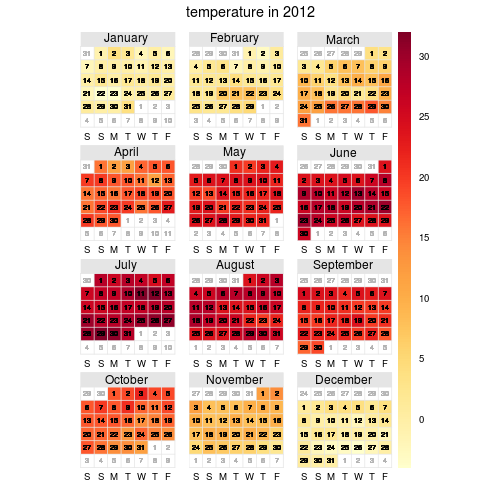

```r
require(openair)
calendarPlot(data_temp, pollutant = "temperature", year = 2012)
```

看上去一大片的红色，感觉郑州好热的样子。

#### 分组展示平均温度：

原链接“挑选出平均温度在22度以上的日子”是用ggplot2绘制的，其实calendarPlot就可以设定breaks参数达到相应的效果：

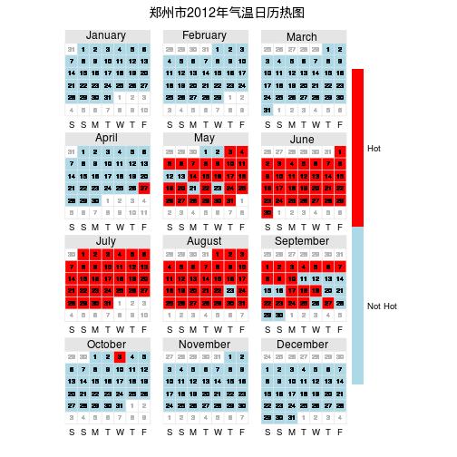

```r
calendarPlot(data_temp, pollutant = "temperature", year = 2012, breaks = c(-10,
    21, 50), labels = c("Not Hot", "Hot"), cols = c("lightblue", "red"), main = "郑州市2012年气温日历热图")
```

仍然是好热的样子，若按“平均温度在22度以上”来定义夏天，郑州倒是有四个半月的夏天了。

### (2)ggplot2包

总觉得原文用ggplot2所作的图坐标轴排反了，作者很忙所以背景也未修饰，尝试自己写一个。基本思路就是绘制散点图，不过以方块的形式绘制，按温度着色并添加文字层。重点在于点的排列，即坐标的计算。

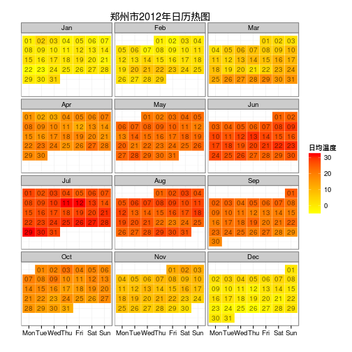

```r
## 获取星期并以有序因子的形式加入数据框
week = weekdays(data_temp$date)
data_temp$week = factor(week, ordered=T,
                        levels=as.character(unique(week)),
                        labels=c('Mon', 'Tue', 'Wed', 'Thu', 'Fri', 'Sat', 'Sun'))
## 获取月份并以有序因子的形式加入数据框
month = substr(months(data_temp$date), 1, 3)
data_temp$month = factor(month, ordered=T,
                         levels = as.character(unique(month)),
                         labels = c("Jan","Feb","Mar","Apr","May","Jun","Jul", "Aug","Sep","Oct","Nov","Dec"))

## 计算绘图所需的y轴坐标: order变量
## 既然是散点图，就需要坐标，横坐标自然就是week变量，关键在于y轴坐标的计算
## 分月计算，每月第一天到该月第一个星期天都排列在第一行，排在最上层，赋值最大。然后计算接下来需要行数，每月天数减去首行天数除以7，其余数便是最后一行的天数，而整数便是首行与末行之间的行数。
data_temp$order = 0
data_final = data.frame()
data_split = split(data_temp, month)
for ( x in data_split) {
  num_top = which(x$week == 'Sun')[1]
  n = nrow(x)
  lines = ceiling((n - num_top) / 7)
  x$order = rep(6:(6-lines), c(num_top, rep(7,lines-1),
                                     n-num_top-(lines-1)*7))
  data_final = rbind(data_final, x)
}

## 绘图
## theme_bw():背景灰色变成白色；xlab/ylab: 坐标轴标题; ggtitle：大标题
## theme(legend.position = "bottom", legend.box = "horizontal") 图例位置
## guides(xx = FALSE) 去除某个图例； theme(legend.position='none')去除所有图例
## 更多细节：theme
require(ggplot2)
p_base = ggplot(data_final, aes(week, order, fill=temperature))
p_base + ggtitle('郑州市2012年日历热图') + geom_tile(colour='white') +
scale_fill_gradient(low="yellow", high="red") + facet_wrap(~month, 4) +
geom_text(aes(label=substr(date, 9, 10), size=2, alpha=0.7)) +
labs(fill='日均温度') +  xlab('') + ylab('') +  # 坐标轴和图例标题
guides(alpha=FALSE, size=FALSE) + theme_bw() + element_blank() +
theme(axis.text.y=element_blank(), axis.ticks.y=element_blank())
```

突出显示高于22度的日子，原文的方法是直接不展示低于22度的日子，可是默认底色太丑导致不太协调，可以在scale_fill_gradient中对na.value进行调整，也可以新建变量对温度分组，再添加映射，一般ggplot2映射出来的配色是很漂亮的，当然也可以自由选取。

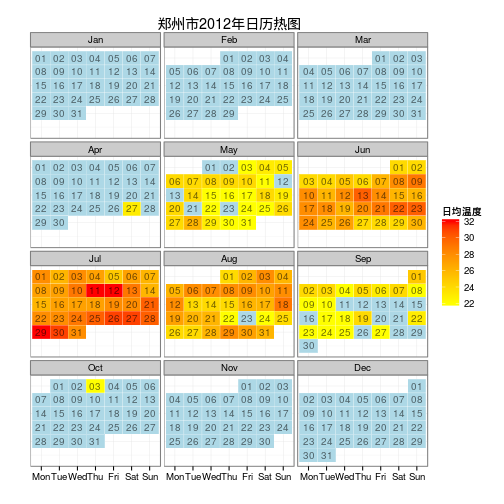

```r
p_base + ggtitle('郑州市2012年日历热图') +
scale_fill_gradient(low="yellow", high="red", na.value='lightblue', limits=c(22, 32)) + geom_tile(colour='white') + facet_wrap(~month, 4) +
geom_text(aes(label=substr(date, 9, 10), size=2, alpha=0.7)) +
labs(fill='日均温度') +  xlab('') + ylab('') +  # 坐标轴和图例标题
guides(alpha=FALSE, size=FALSE) + theme_bw() + element_blank() +
theme(axis.text.y=element_blank(), axis.ticks.y=element_blank())
```